# ESM206 Lab 5

Leana Goetze

10/29/2019

pull frequently (click on blue arrow)

#### Lab 5 Objectives

-Learn to parse dates with ‘lubridate’ -get counts of observations with count() -uncount() rows - one and two-sample t-test -crate a heat map with geom_tile()

Use tidyr::uncount() to convert our lobster data from frequency format to case format

```r
# look in lobster abundance, whatever the value is in lobster_count (however many time it was counted), will just repeat the rows that number of times

lobster_tidy <- lobster_abundance %>%
  tidyr::uncount(lobster_count)
```

#### Exploratory data visualization

We’re only going to consider ‘site’ as our variable of interest

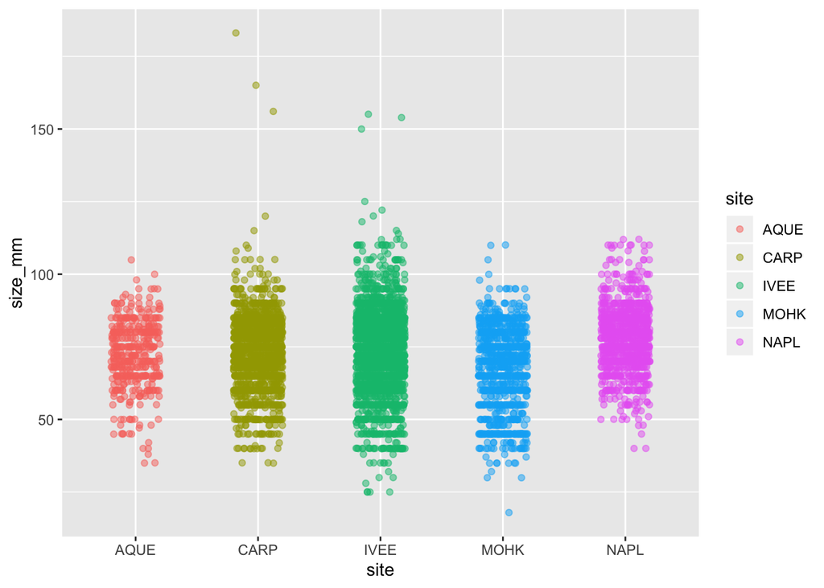

```r
ggplot(lobster_tidy, aes(x = site, y = size_mm)) +
  geom_jitter(aes (color = site),
                   alpha = 0.5,
                   width = 0.2)
```

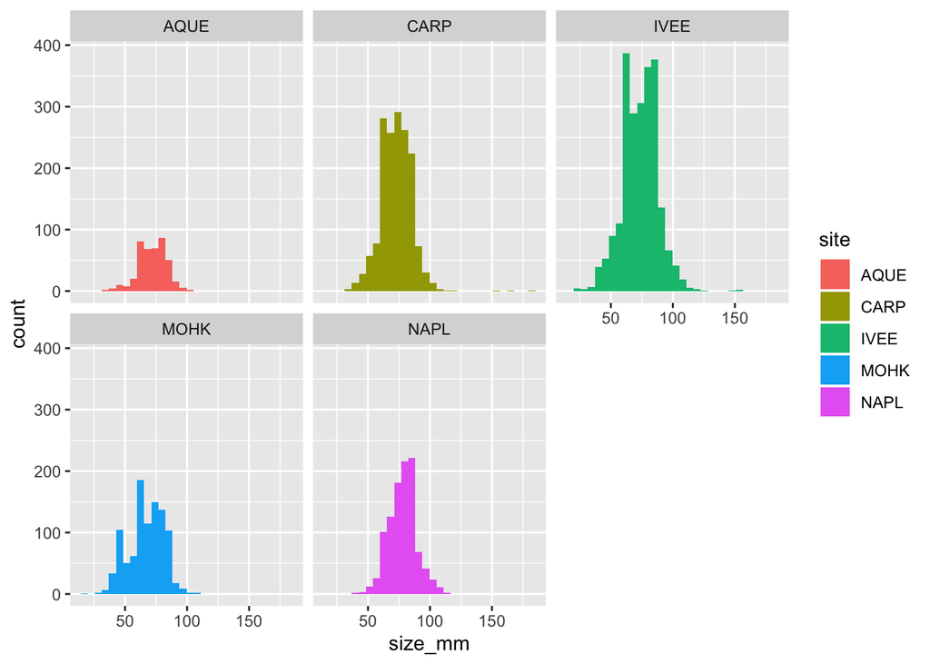

```r
# histogram
ggplot(lobster_tidy, aes (x = size_mm)) +
  geom_histogram(aes(fill = site)) +
  facet_wrap(~site)
```

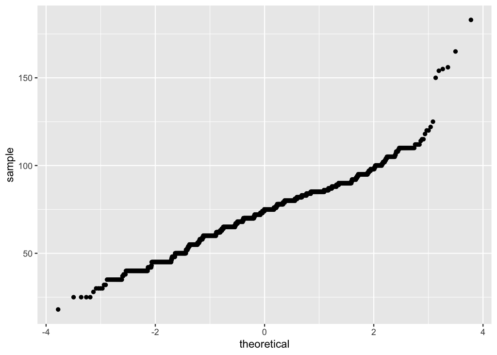

```r
ggplot(lobster_tidy, aes(sample = size_mm)) +
  geom_qq()
```

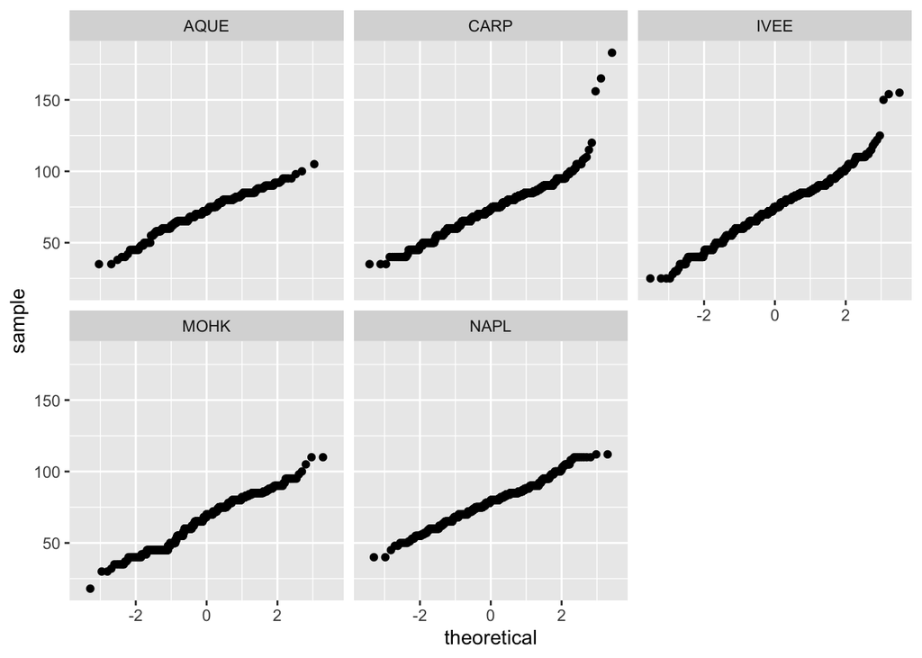

```r
# looks like pretty close to normal distrubtion compared to theoretical normal distribution. but now look at between different site

ggplot(lobster_tidy, aes(sample = size_mm)) +
  geom_qq()+
  facet_wrap(~site)
```

```r
# looking both at histograms and qq plots--> would say these are pretty close to normal distribution

# central limit theorem- means will be normally distributed with >30 sample size
# parametric test- ex. t-test
# even if have very skewed sample, if >30 sample size can still compare means b/c central limit theorem says that means will follow normal distribution. (?)
```

#### convert the ‘date’ column to class ‘date’

We’ll use the ‘lubridate’ package to convert to date format, and then to help us easily parse month & year

```r
lobster_date <- lobster_tidy %>%
  mutate(
    date_new = lubridate::mdy(date)
  )
```

Now let’s parse year and month using lubraidate::month() and lubridate::year()

```r
lobster_parse_date <- lobster_date %>%
  mutate(
    obs_month = lubridate::month(date_new, label = TRUE),
    obs_year = lubridate::year(date_new)
  )

# lubridate month automatically recognized this as an ordered factor, so do not need to reorder or anything!
```

Now let’s find counts of observed lobsters based on different heirarchical groupings:

First, let’s count lobsters by year and month:

```r
lobster_ym <- lobster_parse_date %>%
  dplyr::count(obs_year, obs_month)

lobster_y <- lobster_parse_date %>%
  dplyr::count(obs_year)

lobster_site <-lobster_date %>%
  dplyr::count(site)
```

If we want to create a summary table that contains statistics OTHER than counts by group, it’s easier to use group_by() + n()

```r
lobster_summary <- lobster_parse_date %>%
  group_by(site) %>%
  summarize(
    mean_size = mean(size_mm, na.rm = TRUE),
    sd_size = sd(size_mm, na.rm = TRUE),
    lobster_number = n())

# if just trying to count a group--> use count, if trying to find m,ultiple summary stats use group by + summarize + n
# can also use tally
```

#### find confidence intervals

use t.test() function to find confidence intervals(for one sample) and perform t-tests to compare means of two samples (…and this will be covered conceptually in lectures week 6)

```r
ivee_lobster <- lobster_tidy %>%
  filter(site == "IVEE") %>%
  pull(size_mm)

t.test(ivee_lobster)
```

```
##
##  One Sample t-test
##
## data:  ivee_lobster
## t = 245.23, df = 2302, p-value < 2.2e-16
## alternative hypothesis: true mean is not equal to 0
## 95 percent confidence interval:
##  72.99130 74.16806
## sample estimates:
## mean of x
##  73.57968
```

#### two sample t-test to compare means

null hyp= samples are drawn from pop. with the same mean(?)

we want to ask is there a signifact difference in lobster lengths at naples and mohawk reefs?

we’ve done our necessary exploratory analyses to determine that a two sample t-test for means comparison is appropriate.

```r
napl_sample <- lobster_tidy %>%
  filter(site == "NAPL") %>%
  pull(size_mm)

mohk_sample <- lobster_tidy %>%
  filter(site == "MOHK") %>%
  pull(size_mm)

mn_ttest <- t.test(mohk_sample, napl_sample)

mn_ttest
```

```
##
##  Welch Two Sample t-test
##
## data:  mohk_sample and napl_sample
## t = -19.849, df = 1850.8, p-value < 2.2e-16
## alternative hypothesis: true difference in means is not equal to 0
## 95 percent confidence interval:
##  -12.43436 -10.19806
## sample estimates:
## mean of x mean of y
##  66.86833  78.18454
```

to do this a slightly different way:

```r
lobster_mn <- lobster_tidy %>%
  filter(site %in% c("NAPL", "MOHK"))

mn_ttest2 <- t.test(size_mm ~ site, data = lobster_mn)

mn_ttest2
```

```
##
##  Welch Two Sample t-test
##
## data:  size_mm by site
## t = -19.849, df = 1850.8, p-value < 2.2e-16
## alternative hypothesis: true difference in means is not equal to 0
## 95 percent confidence interval:
##  -12.43436 -10.19806
## sample estimates:
## mean in group MOHK mean in group NAPL
##           66.86833           78.18454
```

```r
mn_ttest2$p.value
```

```
## [1] 1.215408e-79
```

```r
mn_ttest2$statistic
```

```
##         t
## -19.84873
```

must give t-test entire vector of observations, cannot just give thme one value(ex. the mean)